# Домашнее задание 3: EDA. Interactive visualizations

В этом домашнем задании мы будем работь с набором данных, содержащим цены на дома в городе Эймс штата Айова.  
Данные можно найти в `data/ames_house_prices/`. Описание данных - в `data/ames_house_prices/data_description.txt`. Прочитайте описание переменных перед выполнением задания, мы будем им пользоваться, чтоб понять данные.  
Данные взяты с [соревнования](https://www.kaggle.com/c/house-prices-advanced-regression-techniques) на Kaggle.

Этот набор данных имеет много признаков - всё как в реальной жизни. И мы будем анализировать закономерности в этом наборе данных.  
В данном ДЗ мы отработаем некоторые этапы EDA, так как с функционалом для его выполненния вы уже частично знакомы. Этапы полного EDA были рассмотрены в лекции.

0.В процессе работы размещайте вверху ноутбука, импорт всех необходимых вам библиотек. Это хороший стиль ведения нотубука.

```python
!pip install -U kaleido
#!conda install -c plotly plotly=4.14.3
```

```
^C
```

```python
from pathlib import Path
```

```python
import numpy as np
import pandas as pd
import plotly
import seaborn as sns
from matplotlib import pyplot as plt
import cufflinks as cf
import plotly.express as px

cf.go_offline()
cf.set_config_file(offline=False, world_readable=True)
```

В Python есть библиотека для удобной работы с путями: [pathlib](https://realpython.com/python-pathlib/). Часто удобно определить глобальную переменную `DATA` как экземпляр класса `Path`, а потом к нужным нам файлам обращаться используя `DATA/<filename>`.

1.Определите переменную `DATA` как экземпляр класса `Path`. `DATA` должна указывать на путь к папке с данными для задачи. Загрузите `train.csv` в переменную `df_train`, задавая путь через переменую `DATA`.

```python
DATA = Path('\\Users\\Alex\\rd\\python\\l5\\ames_house_prices')
df_train = pd.read_csv(DATA / 'train.csv')
```

2.Выведите информацию о колонках в наборе данных, их типах, количестве null значений в каждой колонке и форме набора данных.

```python
df_train.info()
```

```
<class 'pandas.core.frame.DataFrame'>
RangeIndex: 1460 entries, 0 to 1459
Data columns (total 81 columns):
 #   Column         Non-Null Count  Dtype
---  ------         --------------  -----
 0   Id             1460 non-null   int64
 1   MSSubClass     1460 non-null   int64
 2   MSZoning       1460 non-null   object
 3   LotFrontage    1201 non-null   float64
 4   LotArea        1460 non-null   int64
 5   Street         1460 non-null   object
 6   Alley          91 non-null     object
 7   LotShape       1460 non-null   object
 8   LandContour    1460 non-null   object
 9   Utilities      1460 non-null   object
```

[output cut: 73 more lines]

```python
df_train.isnull().sum().sort_values(ascending=False).head(19)
```

```
PoolQC          1453
MiscFeature     1406
Alley           1369
Fence           1179
FireplaceQu      690
LotFrontage      259
GarageCond        81
GarageType        81
GarageYrBlt       81
GarageFinish      81
GarageQual        81
BsmtExposure      38
BsmtFinType2      38
BsmtFinType1      37
BsmtCond          37
BsmtQual          37
MasVnrArea         8
MasVnrType         8
Electrical         1
dtype: int64
```

```python
df_train._get_numeric_data()
```

|  | Id | MSSubClass | LotFrontage | LotArea | OverallQual | OverallCond | YearBuilt | YearRemodAdd | MasVnrArea | BsmtFinSF1 | ... | WoodDeckSF | OpenPorchSF | EnclosedPorch | 3SsnPorch | ScreenPorch | PoolArea | MiscVal | MoSold | YrSold | SalePrice |
| --- | --- | --- | --- | --- | --- | --- | --- | --- | --- | --- | --- | --- | --- | --- | --- | --- | --- | --- | --- | --- | --- |
| 0 | 1 | 60 | 65.0 | 8450 | 7 | 5 | 2003 | 2003 | 196.0 | 706 | ... | 0 | 61 | 0 | 0 | 0 | 0 | 0 | 2 | 2008 | 208500 |
| 1 | 2 | 20 | 80.0 | 9600 | 6 | 8 | 1976 | 1976 | 0.0 | 978 | ... | 298 | 0 | 0 | 0 | 0 | 0 | 0 | 5 | 2007 | 181500 |
| 2 | 3 | 60 | 68.0 | 11250 | 7 | 5 | 2001 | 2002 | 162.0 | 486 | ... | 0 | 42 | 0 | 0 | 0 | 0 | 0 | 9 | 2008 | 223500 |
| 3 | 4 | 70 | 60.0 | 9550 | 7 | 5 | 1915 | 1970 | 0.0 | 216 | ... | 0 | 35 | 272 | 0 | 0 | 0 | 0 | 2 | 2006 | 140000 |
| 4 | 5 | 60 | 84.0 | 14260 | 8 | 5 | 2000 | 2000 | 350.0 | 655 | ... | 192 | 84 | 0 | 0 | 0 | 0 | 0 | 12 | 2008 | 250000 |
| ... | ... | ... | ... | ... | ... | ... | ... | ... | ... | ... | ... | ... | ... | ... | ... | ... | ... | ... | ... | ... | ... |
| 1455 | 1456 | 60 | 62.0 | 7917 | 6 | 5 | 1999 | 2000 | 0.0 | 0 | ... | 0 | 40 | 0 | 0 | 0 | 0 | 0 | 8 | 2007 | 175000 |
| 1456 | 1457 | 20 | 85.0 | 13175 | 6 | 6 | 1978 | 1988 | 119.0 | 790 | ... | 349 | 0 | 0 | 0 | 0 | 0 | 0 | 2 | 2010 | 210000 |
| 1457 | 1458 | 70 | 66.0 | 9042 | 7 | 9 | 1941 | 2006 | 0.0 | 275 | ... | 0 | 60 | 0 | 0 | 0 | 0 | 2500 | 5 | 2010 | 266500 |
| 1458 | 1459 | 20 | 68.0 | 9717 | 5 | 6 | 1950 | 1996 | 0.0 | 49 | ... | 366 | 0 | 112 | 0 | 0 | 0 | 0 | 4 | 2010 | 142125 |
| 1459 | 1460 | 20 | 75.0 | 9937 | 5 | 6 | 1965 | 1965 | 0.0 | 830 | ... | 736 | 68 | 0 | 0 | 0 | 0 | 0 | 6 | 2008 | 147500 |

1460 rows × 38 columns

3.Датасет, который мы рассматриваем - из решения задачи регрессии. Наша целевая переменная - `SalePrice`. И в задаче регрессии предсказать нужно будет её. Нам важно понять, как она распределена и как взаимодействует с другими переменными.  
Лучше всего моделируются переменные близкие к нормальному распределению.

3.1. Постройте функцию плотности (распределение данных) `SalePrice` с помощью seaborn.

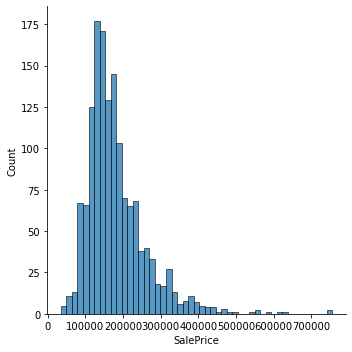

```python
sns.displot(df_train['SalePrice'])

plt.show()
```

3.2. Выведите асимметрию и эксцесс (на английском - skewness and kurtosis) для `SalePrice` (не визуально, ответ в числовом формате).

```python
print("Skewness: %f" % df_train['SalePrice'].skew())
print("Kurtosis: %f" % df_train['SalePrice'].kurt())
```

```
Skewness: 1.882876
Kurtosis: 6.536282
```

Видим, что переменная смещена. То, насколько она похожа на нормальное распределение мы научимся вычислять чуть позже в курсе.

4.Постройте матрицу корреляции, которая будет содержать целевую переменную `SalePrice` и все **числовые**. Отобразите её в виде тепловой карты.  
Числовые переменные необходимо выбрать используя функцию pandas, передавать открыто списком будет считаться неправильным выполнением.  
Если по вашему мнению некоторые переменные необходимо преобразовать в числовые перед построением нужной в этом задании визуализации - преобразуйте, но если не преобразуете, это не будет ошибкой.  
Суть - выделить функцией только числовые переменные и отобразить матрицу корреляции визуально. Не обязательно подписывать при этом значения в клетках матрицы корреляции. Нам важно понять, с чем потенциально хорошо коррелриует таргет, а с чем - нет.

```python
df_train_num = df_train._get_numeric_data()
df_train_num.corr().iplot(kind='heatmap', colorscale="Blues", title="Feature Correlation Matrix")
```

[interactive chart not shown]

```python
#df_train_num.corr()
```

```python
df_train_num.corr()['SalePrice'].sort_values(ascending=False).tail(10)
```

```
BsmtFinSF2      -0.011378
BsmtHalfBath    -0.016844
MiscVal         -0.021190
Id              -0.021917
LowQualFinSF    -0.025606
YrSold          -0.028923
OverallCond     -0.077856
MSSubClass      -0.084284
EnclosedPorch   -0.128578
KitchenAbvGr    -0.135907
Name: SalePrice, dtype: float64
```

```python
df_train_num_corr = df_train_num.corr()['SalePrice'].sort_values(ascending=False).head(10)
```

Какие выводы можно сделать из построенной матрицы корреляций? Какие числовые признаки потенциально сильно влияют на целевую переменную, какие - нет?

OverallQual (качество отделки), GrLivArea (Надземная (земля) жилая площадь), GarageCars (размер гаражей) сильно влияют на целевую переменную

4.1. Найдите top 10 переменных (не включая саму SalePrice), с которыми `SalePrice` имеет наибольшую положительну корреляцию. Выведите эти переменные и корреляцию с ними.

```python
df_train_num.corr()['SalePrice'].sort_values(ascending=False).iloc[1:].head(10)
```

```
OverallQual     0.790982
GrLivArea       0.708624
GarageCars      0.640409
GarageArea      0.623431
TotalBsmtSF     0.613581
1stFlrSF        0.605852
FullBath        0.560664
TotRmsAbvGrd    0.533723
YearBuilt       0.522897
YearRemodAdd    0.507101
Name: SalePrice, dtype: float64
```

4.2. Постройте тепловую карту корреляций только среди переменных `SalePrice` и топ 10, коррелирующих с ней. На тепловой карте выведите числом с двумя цифрами после запятой меру корреляции между каждой парой переменных.

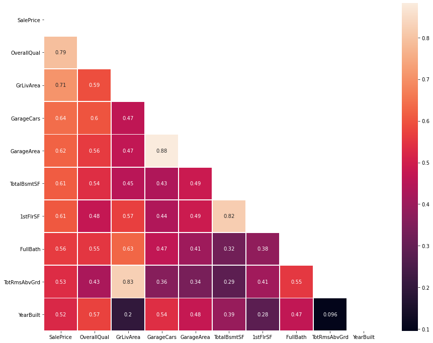

```python
#df_train_num[df_train_num_corr.index].corr().iplot(kind='heatmap', colorscale="Blues", title="Feature Correlation Matrix",annot=True)

plt.figure(figsize=(15, 12))
matrix = np.triu(df_train_num[df_train_num_corr.index].corr())
sns.heatmap(df_train_num[df_train_num_corr.index].corr(), annot=True, linewidth=.8, mask=matrix);
```

4.3. Проанализируйте полученный результат. На ваш взгляд, логично ли, что именно эти признаки наиболее коррелируют с целевой переменной?

Возможно другие показатели были бы логичнее, но показатели из топ-10 тоже соответствуют действительности. Не замечен парадоксальный параметр

5.Постройте треугольный (угловой) pairplot для `SalePrice` и топ 10 признаков в наборе данных, коррелирующих с ней.  
Добавьте линии тренда к данным (параметр `kind`). По диагонали выведите kernel density estimation (kde) переменных.

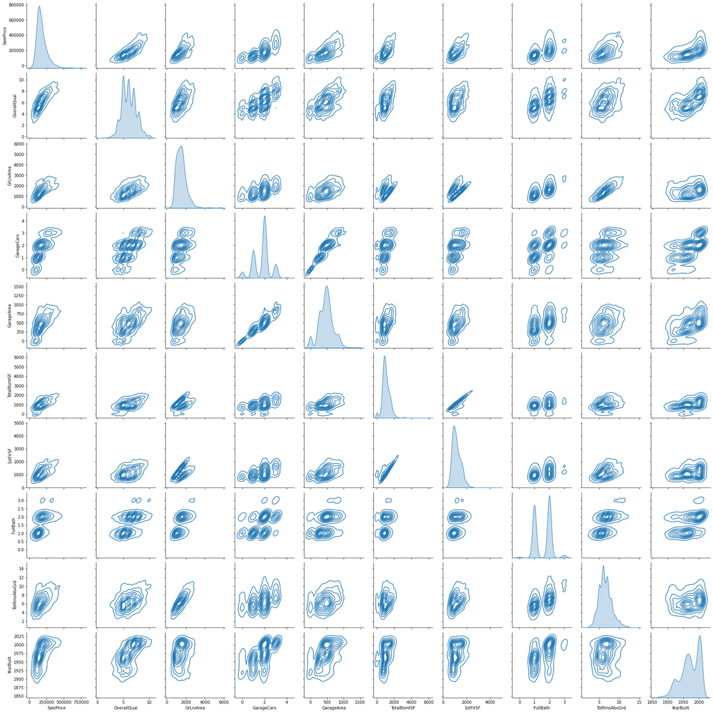

```python
#mydata = sns.load_dataset('tips')
# pairplot with the kind = kde parameter
sns.pairplot(df_train_num[df_train_num_corr.index], kind = 'kde')
# displaying the plot
plt.show()
```

Мы можем видеть точки, которые как будто не попали в общий кластер. Их называют аутлаерами (с англ. outliers) или выбросами. Такими являются, к примеру, точки с невысокой SalePrice и при этом высокое значение GrLivArea, или точка со значением TotalBsmtSF около 6000 и при этом низким SalePrice. Давайте рассмотрим, что это за точки.

5.1. Выведите точки с GrLivArea строго больше 4000.

```python
df_train.loc[df_train['GrLivArea'] > 4000]
```

|  | Id | MSSubClass | MSZoning | LotFrontage | LotArea | Street | Alley | LotShape | LandContour | Utilities | ... | PoolArea | PoolQC | Fence | MiscFeature | MiscVal | MoSold | YrSold | SaleType | SaleCondition | SalePrice |
| --- | --- | --- | --- | --- | --- | --- | --- | --- | --- | --- | --- | --- | --- | --- | --- | --- | --- | --- | --- | --- | --- |
| 523 | 524 | 60 | RL | 130.0 | 40094 | Pave | NaN | IR1 | Bnk | AllPub | ... | 0 | NaN | NaN | NaN | 0 | 10 | 2007 | New | Partial | 184750 |
| 691 | 692 | 60 | RL | 104.0 | 21535 | Pave | NaN | IR1 | Lvl | AllPub | ... | 0 | NaN | NaN | NaN | 0 | 1 | 2007 | WD | Normal | 755000 |
| 1182 | 1183 | 60 | RL | 160.0 | 15623 | Pave | NaN | IR1 | Lvl | AllPub | ... | 555 | Ex | MnPrv | NaN | 0 | 7 | 2007 | WD | Abnorml | 745000 |
| 1298 | 1299 | 60 | RL | 313.0 | 63887 | Pave | NaN | IR3 | Bnk | AllPub | ... | 480 | Gd | NaN | NaN | 0 | 1 | 2008 | New | Partial | 160000 |

4 rows × 81 columns

5.2. Кажется, не все колонки поместились при выведении. Установите параметр пандаса `display.max_columns` равный 100. И выведите запрашиваемые в 5.1 данные ещё раз.

```python
pd.set_option( "display.max_columns", 100)
df_train.loc[df_train['GrLivArea'] > 4000]
```

|  | Id | MSSubClass | MSZoning | LotFrontage | LotArea | Street | Alley | LotShape | LandContour | Utilities | LotConfig | LandSlope | Neighborhood | Condition1 | Condition2 | BldgType | HouseStyle | OverallQual | OverallCond | YearBuilt | YearRemodAdd | RoofStyle | RoofMatl | Exterior1st | Exterior2nd | MasVnrType | MasVnrArea | ExterQual | ExterCond | … |
| --- | --- | --- | --- | --- | --- | --- | --- | --- | --- | --- | --- | --- | --- | --- | --- | --- | --- | --- | --- | --- | --- | --- | --- | --- | --- | --- | --- | --- | --- | --- |
| 523 | 524 | 60 | RL | 130.0 | 40094 | Pave | NaN | IR1 | Bnk | AllPub | Inside | Gtl | Edwards | PosN | PosN | 1Fam | 2Story | 10 | 5 | 2007 | 2008 | Hip | CompShg | CemntBd | CmentBd | Stone | 762.0 | Ex | TA | … |
| 691 | 692 | 60 | RL | 104.0 | 21535 | Pave | NaN | IR1 | Lvl | AllPub | Corner | Gtl | NoRidge | Norm | Norm | 1Fam | 2Story | 10 | 6 | 1994 | 1995 | Gable | WdShngl | HdBoard | HdBoard | BrkFace | 1170.0 | Ex | TA | … |
| 1182 | 1183 | 60 | RL | 160.0 | 15623 | Pave | NaN | IR1 | Lvl | AllPub | Corner | Gtl | NoRidge | Norm | Norm | 1Fam | 2Story | 10 | 5 | 1996 | 1996 | Hip | CompShg | Wd Sdng | ImStucc | None | 0.0 | Gd | TA | … |
| 1298 | 1299 | 60 | RL | 313.0 | 63887 | Pave | NaN | IR3 | Bnk | AllPub | Corner | Gtl | Edwards | Feedr | Norm | 1Fam | 2Story | 10 | 5 | 2008 | 2008 | Hip | ClyTile | Stucco | Stucco | Stone | 796.0 | Ex | TA | … |

5.3. Чем отличаются точки из выбранных те, у которых низкая цена (менее 200000) от тех, у которых цена высокая (более 700000)? Чтобы легче было дать ответ на этот вопрос, отбросьте колонки, в которых записи для выбранных строк одинаковые во всех строках (везде одно и то же число/строка/дата). Сколько колонок получилось в результате отбрасывания мало информативных? Выведите оставшиеся колокни и дайте ответ на заданный в начале этого пункта вопрос.

В ответе дайте свои гипотезы (минимум 3) насчёт отличий с точки зрения признаков (какие признаки более всего влияют на разницу в цене?). Гипотезы отсортируйте по мере спадания гипотетического влияния (то есть , на первом месте самая на Ваш взгляд рабочая гипотеза, на последнем - самая менее рабочая). Цель ранжирования: представьте, что Вам надо определить топ гипотез и выяснить разница в цене случайная, или проблема в данных. У вас на это ограниченное время, что бы вы проверяли в первую очередь?

```python
nunique = df_train.loc[df_train['GrLivArea'] > 4000].apply(pd.Series.nunique)
cols_to_drop = nunique[nunique == 1].index
df_train_4000 = df_train.loc[df_train['GrLivArea'] > 4000].drop(cols_to_drop, axis=1)
df_train_4000.dropna(axis='columns',how='all', inplace=True)
df_train_4000.sort_values(ascending=False, by ="SalePrice")
```

|  | Id | LotFrontage | LotArea | LotShape | LandContour | LotConfig | Neighborhood | Condition1 | Condition2 | OverallCond | YearBuilt | YearRemodAdd | RoofStyle | RoofMatl | Exterior1st | Exterior2nd | MasVnrType | MasVnrArea | ExterQual | BsmtExposure | BsmtFinSF1 | BsmtUnfSF | TotalBsmtSF | 1stFlrSF | 2ndFlrSF | GrLivArea | BsmtFullBath | BsmtHalfBath | FullBath | … |
| --- | --- | --- | --- | --- | --- | --- | --- | --- | --- | --- | --- | --- | --- | --- | --- | --- | --- | --- | --- | --- | --- | --- | --- | --- | --- | --- | --- | --- | --- | --- |
| 691 | 692 | 104.0 | 21535 | IR1 | Lvl | Corner | NoRidge | Norm | Norm | 6 | 1994 | 1995 | Gable | WdShngl | HdBoard | HdBoard | BrkFace | 1170.0 | Ex | Gd | 1455 | 989 | 2444 | 2444 | 1872 | 4316 | 0 | 1 | 3 | … |
| 1182 | 1183 | 160.0 | 15623 | IR1 | Lvl | Corner | NoRidge | Norm | Norm | 5 | 1996 | 1996 | Hip | CompShg | Wd Sdng | ImStucc | None | 0.0 | Gd | Av | 2096 | 300 | 2396 | 2411 | 2065 | 4476 | 1 | 0 | 3 | … |
| 523 | 524 | 130.0 | 40094 | IR1 | Bnk | Inside | Edwards | PosN | PosN | 5 | 2007 | 2008 | Hip | CompShg | CemntBd | CmentBd | Stone | 762.0 | Ex | Gd | 2260 | 878 | 3138 | 3138 | 1538 | 4676 | 1 | 0 | 3 | … |
| 1298 | 1299 | 313.0 | 63887 | IR3 | Bnk | Corner | Edwards | Feedr | Norm | 5 | 2008 | 2008 | Hip | ClyTile | Stucco | Stucco | Stone | 796.0 | Ex | Gd | 5644 | 466 | 6110 | 4692 | 950 | 5642 | 2 | 0 | 2 | … |

1. Тип продажи - SaleType 2. Район - Neighborhood 3. Дата постройки - YearBuilt 4. Дата реконструкции - YearRemodAdd 5. Площадь открытой веранды - OpenPorchSF 6. SaleCondition 7. LandContour

5.4. Постройте диаграмму рассеянИя с помощью Plotly express, в которой по оси ОХ GrLivArea, по оси ОУ SalePrice, цвет - Condition1 и при наведении на точку чтоб выводилась дополнительная информация об id объекта (параметр `hover_data`).

```python
df_train['GrLivArea']
```

```
0       1710
1       1262
2       1786
3       1717
4       2198
        ...
1455    1647
1456    2073
1457    2340
1458    1078
1459    1256
Name: GrLivArea, Length: 1460, dtype: int64
```

```python
import plotly.io as pio
fig = px.scatter(df_train, x = 'GrLivArea', y = 'SalePrice', color ='Condition1', hover_data = ['Id'])
fig.write_image(DATA / "figscat.png")
fig.show()
```

[interactive chart not shown]

Для дома с Id=1299 мы могли бы обосновать низкую цену тем, что он имеет параметр Condition1=FeedR (точки с этим параметром обычно имеют ниже цену), а вот с Id=524 Condition1 = PosN вряд ли влияет негативно на цену, скорее наоборот. Похоже причина низкой цены этих домов - другая.

5.5. Постройте диаграмму рассеянИя с помощью Plotly express, в которой по оси ОХ GrLivArea, по оси ОУ SalePrice, цвет - Neighborhood и при наведении на точку чтоб выводилась дополнительная информация об id объекта.

```python
fig = px.scatter(df_train, x = 'GrLivArea', y = 'SalePrice', color ='Neighborhood', hover_data = ['Id'])
fig.write_image(DATA / "figscat2.png")
fig.show()
```

[interactive chart not shown]

Посмотрите на SalePrice по разным Neighborhood, видите ли вы закономерности?  
Выведите mean, std, min, max, mode значения SalePrice для разных значений Neighborhood (оптимально - с использованием функций groupby() и describe()), отсортируйте значения по убыванию mean, сделайте градиентное закрашивание таблицы. Подтверждаются ли найденные закономерности с диаграммы?

```python
#pd.set_option('display.float_format', '{:.2f}'.format)
df_traindf_train_d = df_train.groupby(by = ['Neighborhood'])['SalePrice'].describe()[['mean','std','min','max','25%','50%','75%' ]].sort_values(by=['mean'])
df_traindf_train_d.style.background_gradient(cmap='RdYlGn', axis=0)
```

| Neighborhood | mean | std | min | max | 25% | 50% | 75% |
| --- | --- | --- | --- | --- | --- | --- | --- |
| MeadowV | 98576.470588 | 23491.049610 | 75000.000000 | 151400.000000 | 83500.000000 | 88000.000000 | 115000.000000 |
| IDOTRR | 100123.783784 | 33376.710117 | 34900.000000 | 169500.000000 | 81000.000000 | 103000.000000 | 120500.000000 |
| BrDale | 104493.750000 | 14330.176493 | 83000.000000 | 125000.000000 | 91000.000000 | 106000.000000 | 118000.000000 |
| BrkSide | 124834.051724 | 40348.689270 | 39300.000000 | 223500.000000 | 100500.000000 | 124300.000000 | 141175.000000 |
| Edwards | 128219.700000 | 43208.616459 | 58500.000000 | 320000.000000 | 101500.000000 | 121750.000000 | 145225.000000 |
| OldTown | 128225.300885 | 52650.583185 | 37900.000000 | 475000.000000 | 105900.000000 | 119000.000000 | 140000.000000 |
| Sawyer | 136793.135135 | 22345.129157 | 62383.000000 | 190000.000000 | 127250.000000 | 135000.000000 | 149462.500000 |
| Blueste | 137500.000000 | 19091.883092 | 124000.000000 | 151000.000000 | 130750.000000 | 137500.000000 | 144250.000000 |
| SWISU | 142591.360000 | 32622.917679 | 60000.000000 | 200000.000000 | 128000.000000 | 139500.000000 | 160000.000000 |
| NPkVill | 142694.444444 | 9377.314529 | 127500.000000 | 155000.000000 | 140000.000000 | 146000.000000 | 148500.000000 |
| NAmes | 145847.080000 | 33075.345450 | 87500.000000 | 345000.000000 | 127500.000000 | 140000.000000 | 158000.000000 |
| Mitchel | 156270.122449 | 36486.625334 | 84500.000000 | 271000.000000 | 131000.000000 | 153500.000000 | 171000.000000 |
| SawyerW | 186555.796610 | 55651.997820 | 76000.000000 | 320000.000000 | 145500.000000 | 179900.000000 | 222500.000000 |
| NWAmes | 189050.068493 | 37172.218106 | 82500.000000 | 299800.000000 | 165150.000000 | 182900.000000 | 205000.000000 |
| Gilbert | 192854.506329 | 35986.779085 | 141000.000000 | 377500.000000 | 174000.000000 | 181000.000000 | 197200.000000 |
| Blmngtn | 194870.882353 | 30393.229219 | 159895.000000 | 264561.000000 | 174000.000000 | 191000.000000 | 213490.000000 |
| CollgCr | 197965.773333 | 51403.666438 | 110000.000000 | 424870.000000 | 152958.750000 | 197200.000000 | 225725.000000 |
| Crawfor | 210624.725490 | 68866.395472 | 90350.000000 | 392500.000000 | 159250.000000 | 200624.000000 | 239000.000000 |
| ClearCr | 212565.428571 | 50231.538993 | 130000.000000 | 328000.000000 | 183750.000000 | 200250.000000 | 242225.000000 |
| Somerst | 225379.837209 | 56177.555888 | 144152.000000 | 423000.000000 | 177975.000000 | 225500.000000 | 252919.500000 |
| Veenker | 238772.727273 | 72369.317959 | 162500.000000 | 385000.000000 | 184250.000000 | 218000.000000 | 282000.000000 |
| Timber | 242247.447368 | 64845.651549 | 137500.000000 | 378500.000000 | 186900.000000 | 228475.000000 | 286115.750000 |
| StoneBr | 310499.000000 | 112969.676640 | 170000.000000 | 556581.000000 | 213500.000000 | 278000.000000 | 377426.000000 |
| NridgHt | 316270.623377 | 96392.544954 | 154000.000000 | 611657.000000 | 253293.000000 | 315000.000000 | 374000.000000 |
| NoRidge | 335295.317073 | 121412.658640 | 190000.000000 | 755000.000000 | 265000.000000 | 301500.000000 | 341000.000000 |

Похоже дома Id=524 и Id=1299 имеют соседство, в котором стоимости домов низкие. Этим возможно и обосновывается цена. Но это только гипотеза.

6.1. C помощью библиотеки missingno выведите в виде bar chart количество отсутствующих значений в колонках датасета. Чтобы просматривать было комфортно, выведите на одной фигуре две панели расположенные вертикально (т.е. вторая под первой), где на первой панели будет информация про отсутствующие значения в первых 40 колонках, а на второй - во всех остальных.

```python
import missingno as msno
```

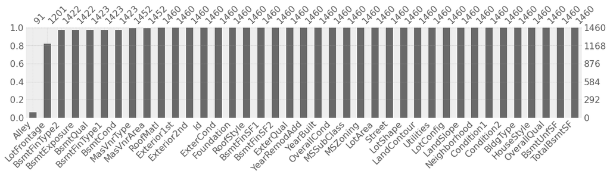

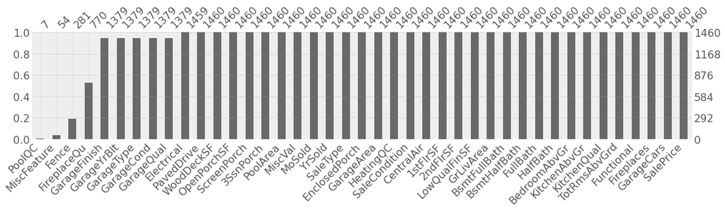

```python
plt.style.use('bmh')
plt.figure(1)
msno.bar(df_train.iloc[:,0:39],sort='ascending',figsize=(18, 3))
plt.figure(2);
msno.bar(df_train.iloc[:,40:],sort='ascending',figsize=(18, 3))
```

Пользуясь визуализацией, определите, в каких колонках отсутствует более половины записей. Ответ - текстом названия колонок.

- PoolQC
- MiscFeature
- Alley
- Fence

6.2.1. Проведём подобный анализ не визуально, а аналитически, чтобы вы имели возможность выбрать то, что вам удобнее. Посчитайте, сколько значений отсутствуют в каждой из колонок датафрейма df_train (используйте функцию isna() и гугл при необходимости).  
Запишите результат в переменную count_na.

```python
count_na = df_train.isna().sum().sort_values(ascending=False).head(19)
count_na
```

```
PoolQC          1453
MiscFeature     1406
Alley           1369
Fence           1179
FireplaceQu      690
LotFrontage      259
GarageCond        81
GarageType        81
GarageYrBlt       81
GarageFinish      81
GarageQual        81
BsmtExposure      38
BsmtFinType2      38
BsmtFinType1      37
BsmtCond          37
BsmtQual          37
MasVnrArea         8
MasVnrType         8
Electrical         1
dtype: int64
```

6.2.2. Пользуясь переменной count_na выведите колонки, у которых процент отсутствующих значений строго более 50. Ответом должна быть структура pd.Series с индексом - название колонки и значениями - процент отсуствующих значений в этой колонке.

```python
count_na[count_na.values > 1460*0.5]*(100/1460)
```

```
PoolQC        99.52
MiscFeature   96.30
Alley         93.77
Fence         80.75
dtype: float64
```

Сравните полученные результаты с теми, что вы указали в п. 6.1, они должны совпадать.

6.3. Выведите матричное отображение отсутствующих значений с помощью библиотеки missingno. Найдите, какое максимальное количество заполненных данных в одной строке и какое - минимальное. Количество заполненных данных в одной строке ограничено сверху количеством колонок.

Внимание: чтобы ответить на заданные вопрос корректно пользуясь визуализацией, вам необходимо вывести тут на **одной** диаграмме **все** колонки сразу (они поместятся).

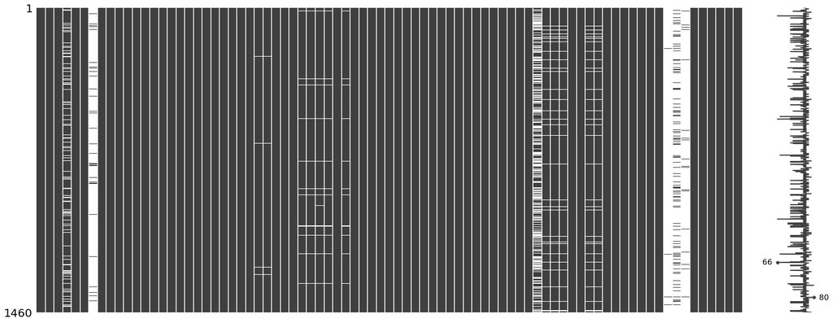

```python
msno.matrix(df_train)
```

Максимальное количество заполненных значений - 80 (строки 1328 и 1386), минимальное количество - 66 (строки 39, 533, 1011, 1218)

# df_train.apply(lambda x: x.count(), axis=1).sort_values(ascending=False)

6.4. Выведите тепловую карту отвутствующих значений с помощью библиотеки missingno.  
Если отсутствуют значения в переменной GarageType, у каких ещё переменных тоже будут отсутствовать значения?

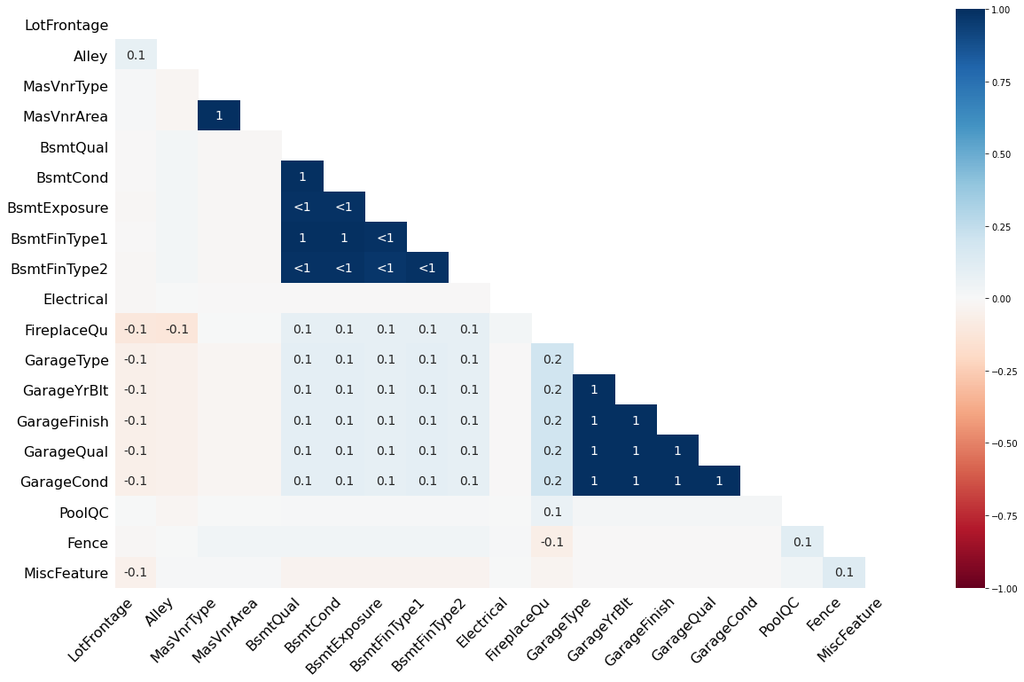

```python
msno.heatmap(df_train)
```

Если отсутствуют значения в переменной GarageType, то будут отсуствовать значения GarageYrBlt, GarageFinish, GarageQual, GarageCond.